# fourT

## Package Structure

[interactive chart not shown]

## Computation Functions

There are four computation functions: ‘compute_gmi’, ‘compute_agp’, ‘compute_wear_time’, and ‘compute_avg_glucose’. Each computation function operates without reference to another, except for ‘compute_gmi’, which calls ‘compute_avg_glucose’; the ‘compute_avg_glucose’ function can also be called independently by the user.

Time control parameters: There are three primary ways in which to time window for computation can be modified:

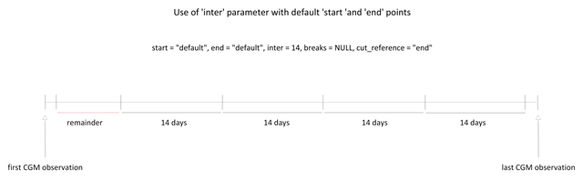

Use of ‘inter’ parameter with default ‘start ’and ’end’ points

The ‘breaks’ parameter allows metrics to be computed at different time points, e.g. 1 month, 2 months, 6 months, 12 months.

Example 2: start = “default”, end = “default”, breaks = c(0, 1, 3, 6, 12)

Example 3:

```r
  df_dex <- read_dexcom("~/Desktop/R Workspace/4T/external files/4T.399_Clarity_Export_00123_Doe_John_2024-05-01_162849.csv")
  fourT::compute_gmi(df_dex = df_dex, start = "default", end = "default", inter = 14, breaks = c(0, 1, 3, 6, 12))
```

```
#> Error in fourT::compute_gmi(df_dex = df_dex, start = "default", end = "default", : unused argument (inter = 14)
```

## Helper functions

The only helper function currently in the package is the ‘read_dexcom’ function. This reads a patient .csv file, removes sensitive patient health information and converts the file into the correct format to apply computation and visualization functions.

## Development

Branching

Recording Issues

## Next Steps for fourT Package

Full walkthrough on package use

One can read a patient file as follows …

```r
#read_dexcom(filepath, F)
#View(read_dexcom(filepath, F))
```

[^1]: Prahalad, P., Scheinker, D., Desai, M. et al. Equitable implementation of a precision digital health program for glucose management in individuals with newly diagnosed type 1 diabetes. Nat Med 30, 2067–2075 (2024). https://doi.org/10.1038/s41591-024-02975-y